# Sampling Distributions

### 1.6.2 Exponential Distribution

The Exponential Distribution is defined by the following probability *density function*, where $\dfrac{1}{\lambda}$ is the population mean and the standard deviation.

$f(x) = \lambda e^{-\lambda x}$

If a random variable $X$ follows the Exponential Distribution, then we write: $X \sim Exp(\lambda)$

Here is how the Exponential density looks like: Ex: here $X \sim Exp(1/15)$

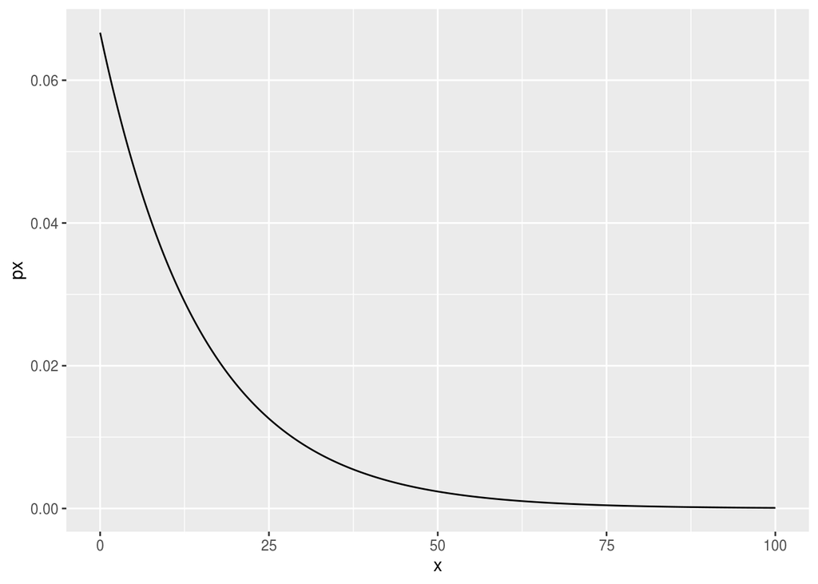

#### 1.6.2.1 R functions for Exponential Distribution

*Package: stats*

1. Generate a random sample of 100 from $Exp(1/15)$ and create a histogram.

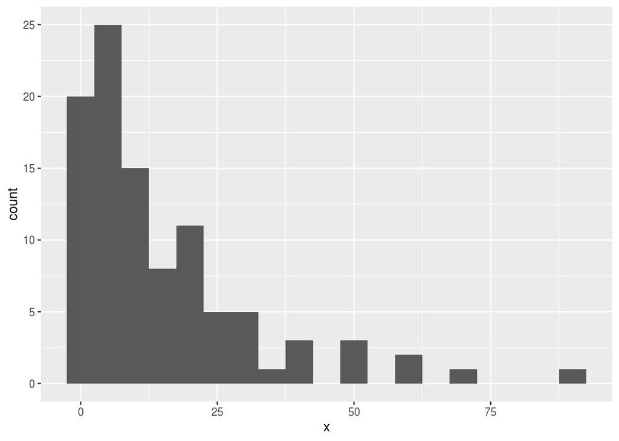

```r
x <- rexp(n = 100, rate = 1/15)
ggplot(data.frame(x), aes(x = x)) + geom_histogram(binwidth = 5)
```

2. If $X \sim Exp(1/15)$ find the probability that X being less than 21: $P(X<21)$

```r
pexp(21, rate = 1/15)
```

```
## [1] 0.753403
```

3. If $X \sim Exp(1/15)$ find the 75th quantile.

```r
qexp(.75, rate = 1/15)
```

```
## [1] 20.79442
```

##### 1.6.2.1.1 Exercise

The number of days ahead travelers purchase their airline tickets can be modeled by an exponential distribution with the average amount of time equal to 15 days.

$X \sim Exp(1/15)$

1. Find the probability that a traveler will purchase a ticket fewer than ten days in advance.

```r
pexp(10, rate = 1/15)
```

```
## [1] 0.4865829
```

2. How many days in advance do 80% of all travelers purchase their airline tickets?

```r
qexp(.2, rate = 1/15)
```

```
## [1] 3.347153
```

### 1.6.3 Binomial Distribution

The binomial distribution is a *discrete* probability distribution. It describes the outcome of n independent trials in an experiment. Each trial is assumed to have only two outcomes, either success or failure. If the probability of a successful trial is $p$, then the probability of having $x$ successful outcomes in an experiment of $n$ independent trials is as follows:

$f(x) = {n \choose x} p^x (1-p)^{(n-x)} \quad \text{where x = 0, 1, 2,...,n}$

Example: Suppose there are twelve multiple choice questions in an English class quiz. Each question has five possible answers, and only one of them is correct.

1. Find the probability of having exactly four correct answers if a student attempts to answer every question at random.
1. By hand

${12 \choose 4} 0.2^4 (1-0.2)^{(12-4)} = 0.1329$

2. In R

```r
dbinom(4, size=12, prob=0.2)
```

```
## [1] 0.1328756
```

2. Find the probability of having four or less correct answers if a student attempts to answer every question at random.
1. By hand

${12 \choose 4} 0.2^4 (1-0.2)^{(12-4)} + {12 \choose 3} 0.2^3 (1-0.2)^{(12-3)} + {12 \choose 2} 0.2^2 (1-0.2)^{(12-2)} + {12 \choose 1} 0.2^1 (1-0.2)^{(12-1)} + {12 \choose 0} 0.2^0 (1-0.2)^{(12-0)} = 0.9274$

2. In R

```r
xs = c(0:4)
sum = 0
for (x in xs) {
    sum = sum + dbinom(x, size=12, prob=0.2)
}
sum
```

```
## [1] 0.9274445
```

```r
#there is a function to do this but I don't know the name
```

## 1.7 Theoritical Sampling Distribution of the Proportion

Sampling distribution of $\hat{p}$ is normal with mean $p$ (Actual population proportion) and standard deviation of $\sqrt{p(1-p)/n}$

$\hat{p} \sim N( p, \sqrt{p(1-p)/n} )$

Let’s revisit the coin flip example. Check how close our simulation results are to the theoretical results.

```r
mean(vp$pHeads)
```

```
## [1] 0.50366
```

```r
sd(vp$pHeads)
```

```
## [1] 0.1597301
```

Now let’s find the theoretical mean and the standard deviation the sampling distribution of the proportion:

Here $p=0.5, n=10$

$\hat{p} \sim N( p, \sqrt{p(1-p)/n} ) = N( 0.5, \sqrt{0.5(1-0.5)/10} ) = N( 0.5, 0.1581139)$

## 1.8 Sampling Distribution of the Mean

1. Let’s simulate the sampling distribution of the mean of a normal distribution with $N(10, 3^2)$
- Draw 1000 samples of size $n=100$ from this distribution and compute the mean for each sample, and store the mean in a vector called `Xbars`
- It looks like, in this case, the histogram suggests that the sampling distribution of the sample mean has a *normal* distribution.
- Find the mean and the standard error of the sampling distribution of the sample mean $\bar{X}$

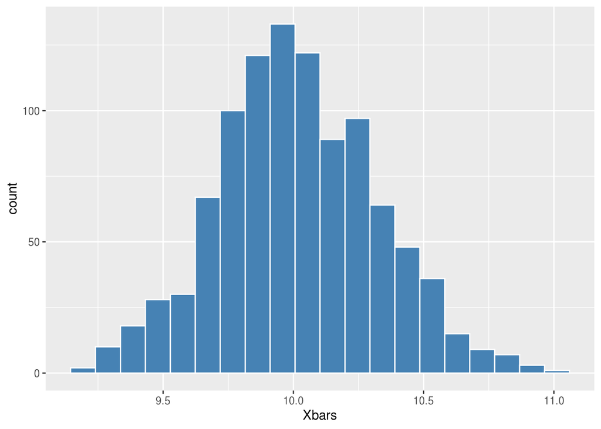

```r
Xbars = numeric(1000)
for (i in 1:1000) {
    x = rnorm(n = 100, mean = 10, sd = 3)
    Xbars[i] = mean(x)
}

ggplot(data.frame(Xbars), aes(x = Xbars)) + geom_histogram(bins = 20, color = "white", fill = "steelblue")
```

```r
mean(Xbars)
```

```
## [1] 10.01729
```

```r
sd(Xbars)
```

```
## [1] 0.3069137
```

2. Let’s simulate the sampling distribution of the mean of a exponential distribution with $Exp(1/15)$
- Draw 1000 samples of size $n=100$ from this distribution and compute the mean for each sample, and store the mean in a vector called `Xbars2`
- It looks like, in this case, the histogram suggests that the sampling distribution of the sample mean has a *normal* distribution.
- Find the mean and the standard error of the sampling distribution of the sample mean $\bar{X}$

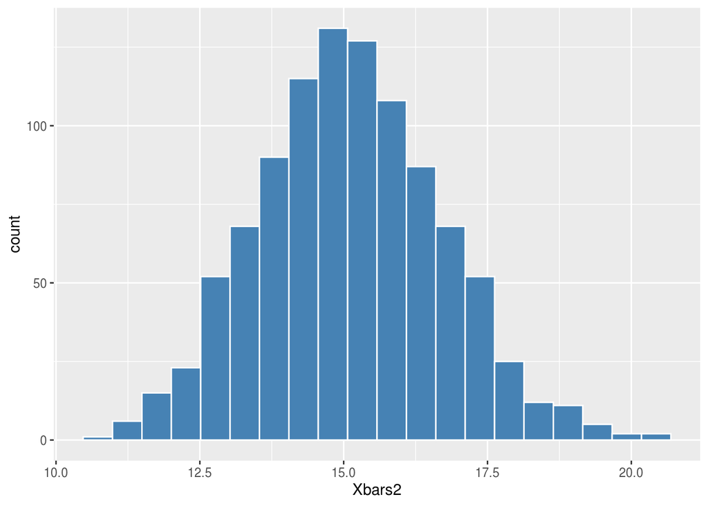

```r
Xbars2 = numeric(1000)
for (i in 1:1000) {
    x = rexp(n = 100, rate = 1/15)
    Xbars2[i] = mean(x)
}

ggplot(data.frame(Xbars2), aes(x = Xbars2)) + geom_histogram(bins = 20, color = "white", fill = "steelblue")
```

```r
mean(Xbars2)
```

```
## [1] 15.11208
```

```r
sd(Xbars2)
```

```
## [1] 1.59396
```

## 1.9 The central limit theorem (CLT)

For a large sample size (rule of thumb: $n≥30$), the sample mean $\bar{X}$ is approximately normally distributed, regardless of the distribution of the population one samples from. If the population has mean $\mu$ and standard deviation $\sigma$, then $\bar{X}$ has mean and standard error $\sigma/ \sqrt{n}$

Therefore, according to the CLT: $\bar{X} \sim N(\mu, \sigma/ \sqrt{n})$

Note that the spread of the sampling distribution of the mean decreases as the sample size increases.

1. Now that we know the theoretical sampling distribution of $\bar{X}$:
1. Find the theoretical sampling distribution of $\bar{X}$ for question 1 above and compare those with the simulated results.
   - $\bar{X} \sim N(10, 3/ \sqrt{100})$
   - $\bar{X} \sim N(10, 0.3)$
2. Find the theoretical sampling distribution of $\bar{X}$ for question 2 above and compare those with the simulated results.
   - $\bar{X} \sim N(15, 15/ \sqrt{100})$
   - $\bar{X} \sim N(15, 1.5)$

*Note: In this class, we only have theoritical sampling distributions for $\hat{p}$ and $\bar{X}$ only. For other sample statistics like median, min, max, etc. we would only have the simulated results.*

# 2 Problem Solving

## 2.1 Example

*Finding probabilities using a sampling distribution.*

The engines made by Ford for speedboats had an average power of 220 horsepower (HP) and standard deviation of 15 HP.

A potential buyer intends to take a sample of four engines and will not place an order if the sample mean is less than 215 HP. What is the probability that the buyer will not place an order? Assume that the parent distribution is Normal.

1. Answer the question using a theoretical distribution:

$Pr(\bar{X}<215)= ?$

$\bar{X} \sim N(\mu, \dfrac{\sigma}{\sqrt{n}})$

$\bar{X} \sim N(220, \dfrac{15}{\sqrt{4}})$

$\bar{X} \sim N(220, 7.5)$

```r
pnorm(215, mean = 220, sd = 7.5)
```

```
## [1] 0.2524925
```

2. Answer the question using a simulation:

```r
Xbars = numeric(1000)
for (i in 1:1000) {
    x = rnorm(n = 4, mean = 220, sd = 15)
    Xbars[i] = mean(x)
}
mean(Xbars < 215)
```

```
## [1] 0.244
```

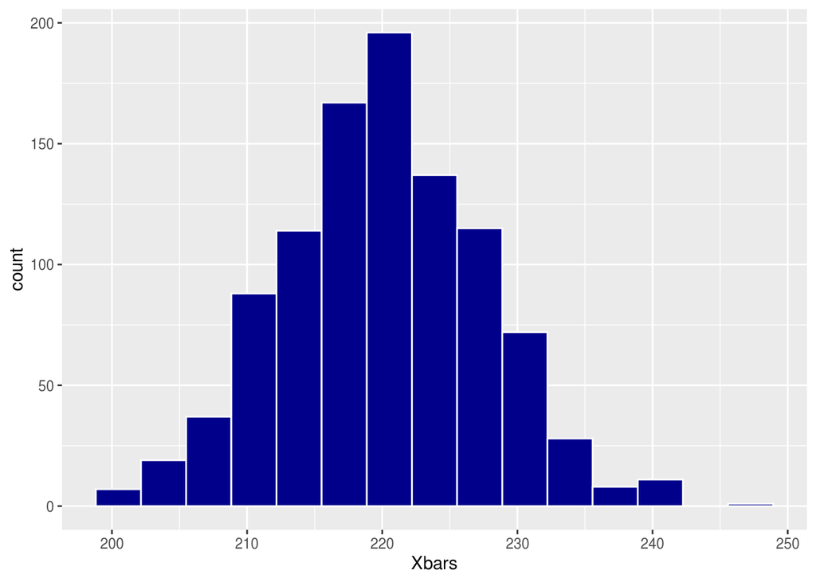

```r
ggplot(data.frame(Xbars), aes(x=Xbars)) + geom_histogram(color = "white", fill = "blue4", bins = 15)
```

## 2.2 Example

A friend claim that she has drawn a random sample of size 30, from the exponential distribution $(f(x) = \lambda e^{-\lambda x})$ with $\lambda = 1/10$

The mean of her sample is 12.

1. What is the mean (expected value) of a sample mean?

```r
#10
```

2. Run a simulation by drawing 100,000 random samples, each of size 30, from $\text{Exp}(\lambda = 1/10)$ and then compute the mean. What proportion of the sample means are as large as or larger than 12?

```r
sims = 100000
Xbars = numeric(sims)
for (i in 1:sims) {
    x = rexp(n = 30, rate = 1/10)
    Xbars[i] = mean(x)
}
mean(Xbars > 12)
```

```
## [1] 0.13665
```

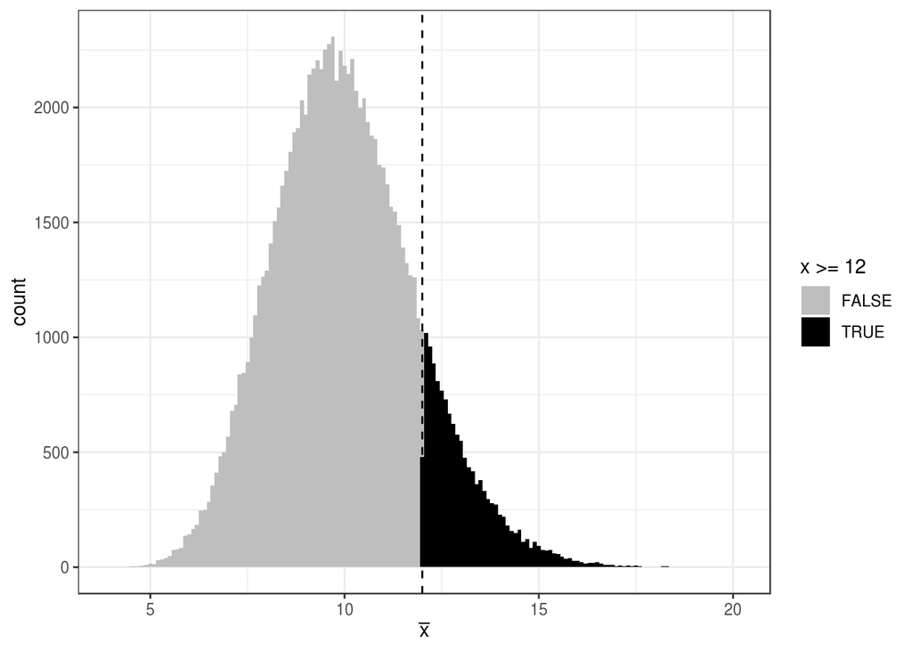

```r
ggplot(data.frame(x = Xbars), aes(x = x, fill = x >= 12)) +
    geom_histogram(binwidth = 0.1) +
    theme_bw() +
    labs(x = expression(bar(x))) +
    geom_vline(xintercept = 12, linetype = "dashed") +
    scale_fill_manual(values = c("grey", "black"))
```

Is a mean of 12 unusual for a sample of size 30 from $\text{Exp}(\lambda = 1/10)$?

## 2.3 Example

Consider the population `{3, 5, 6, 6, 8, 11, 13, 15, 19, 20}`.

1. Compute the mean and standard deviation and create a histogram of its distribution.

```r
v = c(3, 5, 6, 6, 8, 11, 13, 15, 19, 20)
mean(v)
```

```
## [1] 10.6
```

```r
sd(v)
```

```
## [1] 5.985167
```

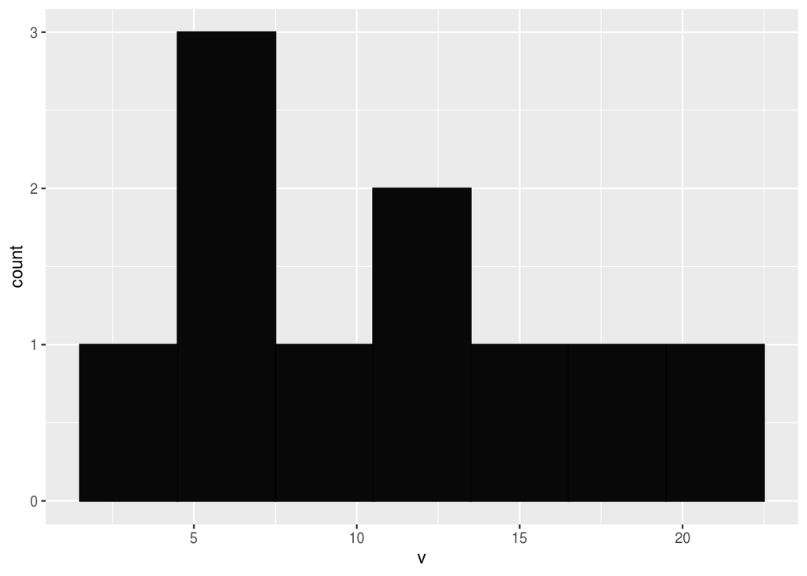

```r
ggplot(data.frame(v), aes(x=v)) + geom_histogram(color = "grey1", fill = "grey3", binwidth = 3)
```

2. Simulate the sampling distribution of $\bar{X}$ by taking random samples of size 4 and plot your results. Compute the mean and standard error, and compare to population mean and standard deviation.

```r
sims = 100000
Xbars = numeric(sims)
for (i in 1:sims) {
    x = sample(v, size = 4)
    Xbars[i] = mean(x)
}
mean(Xbars)
```

```
## [1] 10.59529
```

```r
sd(Xbars)
```

```
## [1] 2.320792
```

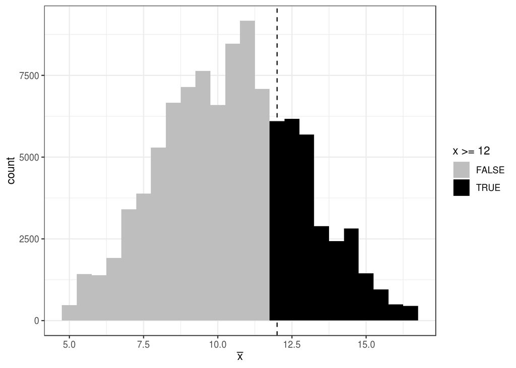

```r
ggplot(data.frame(x = Xbars), aes(x = x, fill = x >= 12)) +
    geom_histogram(binwidth = 0.5) +
    theme_bw() +
    labs(x = expression(bar(x))) +
    geom_vline(xintercept = 12, linetype = "dashed") +
    scale_fill_manual(values = c("grey", "black"))
```

3. Use the simulation to find $P(\bar{X}<11)$

```r
mean(Xbars < 11)
```

```
## [1] 0.54297
```

## 2.4 Example

Suppose the heights of boys in a certain city follow a normal distribution with mean 48 in and variance 9^2.

1. Use the CLT to estimate the probability that in a random sample of 30 boys, the mean height is more than 51 in.

```r
1 - pnorm(51, mean = 48, sd = 9/sqrt(30))
```

```
## [1] 0.03394458
```

2. Use a simulation to redo part 1.

```r
sims = 100000
Xbars = numeric(sims)
for (i in 1:sims) {
    x = rnorm(n = 30, mean = 48, sd = 9)
    Xbars[i] = mean(x)
}
mean(Xbars > 51)
```

```
## [1] 0.03408
```

## 2.5 Example

The engines made by Ford for speedboats had an average power of 220 horsepower (HP) and standard deviation of 15 HP.

A potential buyer intends to take a sample of four engines and will not place an order if the sample *median* is less than 215 HP. What is the probability that the buyer will not place an order? Assume that the parent distribution is Normal.

1. Answer the question using a theoretical distribution:

**NOT TAUGHT IN THIS CLASS**

2. Answer the question using a simulation:

```r
Medians = numeric(1000)
for (i in 1:1000) {
    x = rnorm(n = 4, mean = 220, sd = 15)
    Medians[i] = median(x)
}
mean(Medians < 215)
```

```
## [1] 0.283
```

## 2.6 Example

4. Let $X_1, X_2, \ldots , X_{10} \overset{i.i.d}\sim N(20, 8)$ and $Y_1, Y_2, \ldots, Y_{15} \overset{i.i.d}\sim N(16, 7)$. Let $W = \bar{X} + \bar{Y}$.

The exact sampling distribution of $W$ is:

$N\left(mean = \mu_1 + \mu_2, sd = \sqrt{\sigma_1^2/n_1 + \sigma_2^2/n_2}\right)$

$N\left(20 + 16, \sqrt{8^2/10 + 7^2/15}\right) = N(36, 3.11)$

2. Simulate the sampling distribution in `R` and plot your results. Check that the simulated mean and standard error are close to the theoretical mean and standard error.

```r
sims = 100000
Wbars = numeric(sims)
for (i in 1:sims) {
    x = rnorm(n = 10, mean = 20, sd = 8)
    y = rnorm(n = 15, mean = 16, sd = 7)
    Wbars[i] = mean(x) + mean(y)
}
mean(Wbars)
```

```
## [1] 36.0066
```

```r
sd(Wbars)
```

```
## [1] 3.102585
```

3. Use your solution to find $P(W < 40)$.

$\widehat{P(W < 40)} = 0.9011$

## 2.7 Example

The data set `Recidivism` contains the population of all Iowa offenders convicted of either a felony or misdemeanor who were released in 2010 (Case study in Section 1.4) Of these, 31.6% recidivated and were sent back to prison. Simulate the sampling distribution of $\hat{p}$, the sample proportion of offenders who recidivated, for random samples of size 25.

1. Create a histogram and describe the simulated sampling distribution of $\hat{p}$. Estimate the mean and the standard error.

```r
library(resampledata)
data("Recidivism")
sims = 100000
Xbars = numeric(sims)
for (i in 1:sims) {
    x = sample(Recidivism$Recid, size = 25)
    Xbars[i] = mean(x == "Yes")
}
mean(Xbars)
```

```
## [1] 0.3168336
```

```r
sd(Xbars)
```

```
## [1] 0.09279955
```

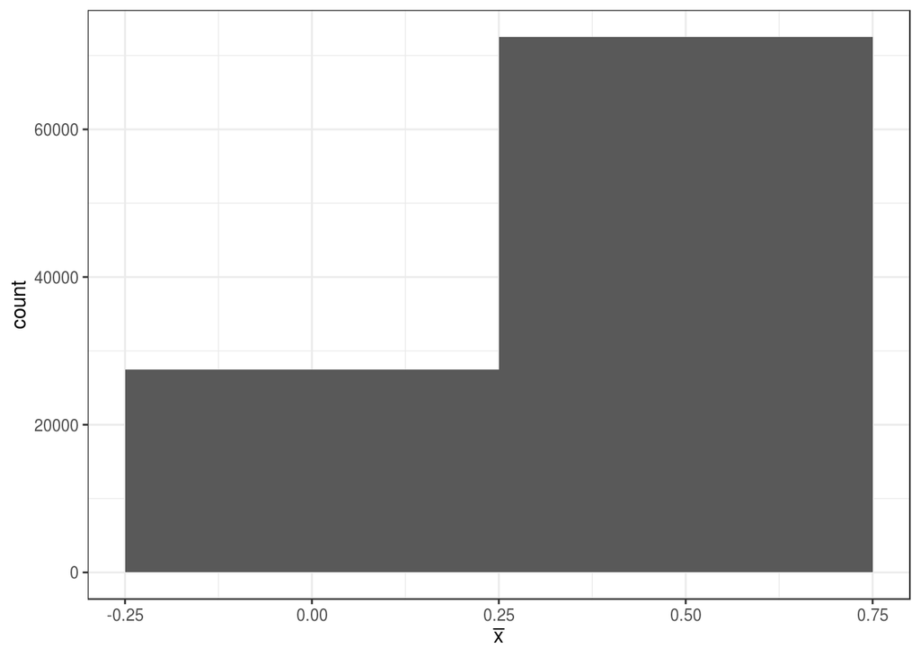

```r
ggplot(data.frame(x = Xbars), aes(x = x)) +
    geom_histogram(binwidth = 0.5) +
    theme_bw() +
    labs(x = expression(bar(x)))
```

2. Compare your estimate with the mean and standard error with the theorerical mean and standard error.

```r
p = 0.316
sterr = sqrt(p * (1 - p) / 25)
p
```

```
## [1] 0.316
```

```r
stderr
```

[output not shown]

3. Repeat the above (part a and b) using samples of size 250, and compare with the $n=25$ case.